# Marker gene based cell type assignment: scType

## Set Up

```r
suppressPackageStartupMessages({
  library(SingleCellExperiment)
  library(ggplot2)
})
theme_set(theme_bw())
```

Here load in the libraries and source in the functions that we need to run `scType`.

```r
# scType dependencies:
# need to have openxlsx and HGNChelper installed
# also need HGNChelper loaded
library(HGNChelper)

# load gene set preparation function
source(\https://raw.githubusercontent.com/IanevskiAleksandr/sc-type/master/R/gene_sets_prepare.R\)
# load cell type annotation function
source(\https://raw.githubusercontent.com/IanevskiAleksandr/sc-type/master/R/sctype_score_.R\)
# database
database_file <- \https://raw.githubusercontent.com/IanevskiAleksandr/sc-type/master/ScTypeDB_full.xlsx\
```

```r
# build path to annotated sce file
annotated_sce_file <- glue::glue(\SCPCL000295_annotated.rds\)
local_annotated_sce_path <- file.path(\..\, \data\, \SCPCS000221\, annotated_sce_file)

# read in all annotated sce
annotated_sce <- readr::read_rds(local_annotated_sce_path)
```

`scType` requires a list of marker genes for each cell type in the reference. We can use their database that they have available, but it’s an excel file that only contains gene symbols. They have a function that opens that excel file and grabs the gene sets of interest and then returns a list of a list of marker genes. I think if we want to explore `scType` further we could think about using their reference and converting to ensembl IDs and doing some more data wrangling to get it to work with our SCE objects. But for the sake of not spending too much time on this right now, I decided to read in our references that we trained with `SingleR` and grab the lists of marker genes from those references.

```r
# grab models from S3 and read in
# we need the models to get a list of marker genes for each of the cell types
s3_model_dir <- \s3://scpca-references/celltype/singler_models\
local_model_dir <- file.path(\..\, \singler_models\)

model_filenames <- c(
  \BlueprintEncodeData_model.rds\,
  \no_immune-BlueprintEncodeData_model.rds\
)

local_model_files <- file.path(local_model_dir, model_filenames)

# if missing any of the model files, grab them from S3
if(!(all(file.exists(local_model_files)))){
  # sync models
  aws_includes <- glue::glue('--include \{model_filenames}\')

  sync_call <- glue::glue('aws s3 sync {s3_model_dir} {local_model_dir}  --exclude \*\ {aws_includes}')
  purrr::walk(sync_call, \(call) system(call, ignore.stdout = TRUE))
}

# read in all refs
model_list <- purrr::map(local_model_files, readr::read_rds) |>
  purrr::set_names(model_filenames)
```

## ScType

`scType` will assign a score for each barcode for each type present in the provided celltypes. Then to assign cell type labels, the scores for all cells in a cluster are summed together and the label with the top score is chosen. This means that one label is assigned to all scores in a cluster. To assign `NA` cells, it appears that they take any cells with a score that’s in the lower 25% of the scores, but that part is more unclear. I followed the guidelines in the [README of the Github page](https://github.com/IanevskiAleksandr/sc-type) and created the function below to annotate celltypes provided a reference model.

```r
# function for running sctype and creating a results table
sctype_scores <- function(annotated_sce,
                          model){

  # grab the unique celltypes
  celltypes <- model$labels$unique

  # get a list of all markers for each celltype
  all_markers <- purrr::map(celltypes,
                            \(label){

                              # grab the markers for each celltype
                              markers <- unique(unlist(model$markers$full[[label]]))

                            }) |>
    purrr::set_names(celltypes)

  # get the assigned score for each cell for each celltype
  celltype_mtx <- sctype_score(scRNAseqData = as.matrix(logcounts(annotated_sce)),
                               scaled = TRUE,
                               gs = all_markers,
                               gs2 = NULL)

  return(celltype_mtx)
}
```

```r
sctype_per_cell <- function(celltype_mtx){

  per_cell_assignment <- celltype_mtx |>
    t() |>
    as.data.frame() |>
    tibble::rownames_to_column(\barcode\) |>
    tidyr::pivot_longer(cols = !\barcode\,
                        names_to = \celltype\,
                        values_to = \score\) |>
    dplyr::group_by(barcode) |>
    dplyr::top_n(n = 1, wt = score) |>
    dplyr::mutate(celltype = ifelse(score < 0.25, 'NA', celltype))

  return(per_cell_assignment)
}
```

```r
sctype_per_cluster <- function(annotated_sce,
                               celltype_mtx){

  # assign clusters for the sce object
  pcs <- reducedDim(annotated_sce, \PCA\)
  annotated_sce$clusters <- bluster::clusterRows(pcs,
                                                 bluster::NNGraphParam(cluster.fun = \louvain\,
                                                                      type = \jaccard\))

  # extract the barcode and clusters information from coldata
  coldata_df <- as.data.frame(colData(annotated_sce)) |>
    tibble::rownames_to_column(\barcode\) |>
    dplyr::select(barcode, clusters)

  # make a matrix of all the scores for all barcodes, clusters, and label combinations
  score_mtx <- celltype_mtx |>
    t() |>
    as.data.frame() |>
    tibble::rownames_to_column(\barcode\) |>
    dplyr::left_join(coldata_df) |>
    tidyr::pivot_longer(cols = !c(\barcode\, \clusters\),
                        names_to = \celltype\,
                        values_to = \score\)

  # summarize the scores by clusters and celltype so that all scores are summed across all barcodes
  # for each label in a cluster
  summarized_scores_mtx <- score_mtx |>
    dplyr::group_by(clusters, celltype) |>
    dplyr::summarise(sum_score = sum(score))

  # assign labels for each cluster, final number of rows should be equal to the number of clusters
  # obtain one celltype label per cluster
  cluster_celltypes <- summarized_scores_mtx |>
    dplyr::group_by(clusters) |>
    dplyr::add_count() |>
    dplyr::top_n(n = 1, wt = sum_score)

  # map everything back to each cell so that each cell receives a label
  per_cluster_assignments <- coldata_df |>
    dplyr::left_join(cluster_celltypes) |>
    # get the score associated with the label assigned to that cell
    dplyr::left_join(score_mtx) |>
    dplyr::mutate(celltype = ifelse(score < n/4, 'NA', celltype))

  return(per_cluster_assignments)

}
```

```r
# run sctype for both references
sctype_results <- purrr::map(model_list,
                             \(model) sctype_scores(model = model$label.main,
                                                    annotated_sce = annotated_sce))
# label based on per cell max score
per_cell_results <- purrr::map(sctype_results, sctype_per_cell)

# label based on max cluster score
per_cluster_results <- purrr::map(sctype_results,
                                  \(result) sctype_per_cluster(annotated_sce = annotated_sce,
                                                               celltype_mtx = result))
```

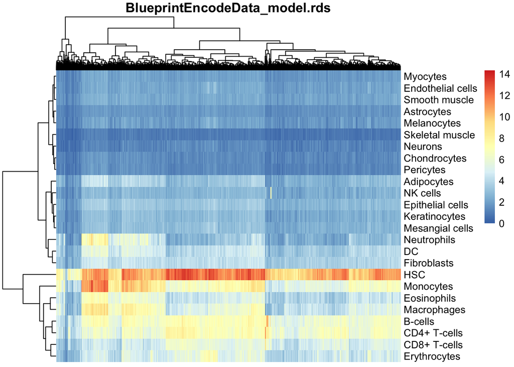

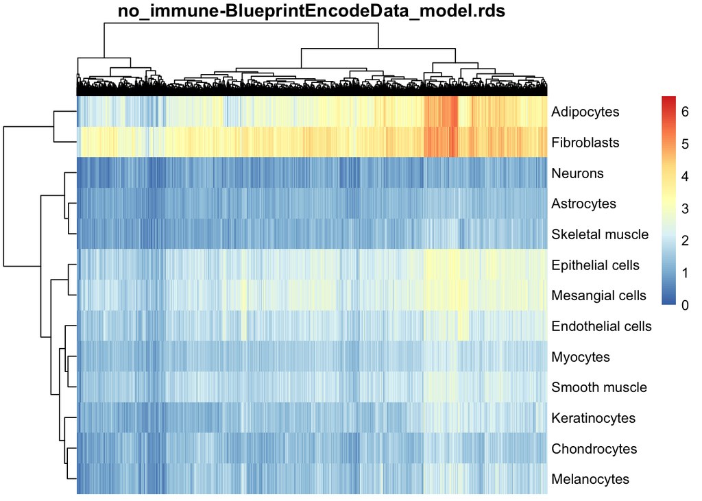

```r
sctype_results |>
  purrr::iwalk(\(scores, title){
    pheatmap::pheatmap(scores,
                       show_colnames = FALSE,
                       main = title)
  })
```

```r
# print out the table of celltype results on a per cell level
per_cell_results |>
  purrr::map(\(result){
    table(result$celltype,
          useNA = \ifany\)
  })
```

```
$BlueprintEncodeData_model.rds

     B-cells CD4+ T-cells  Eosinophils          HSC  Macrophages    Monocytes     NK cells
          26           20            4         4942            1          458            1

$`no_immune-BlueprintEncodeData_model.rds`

       Adipocytes      Chondrocytes Endothelial cells  Epithelial cells       Fibroblasts   Mesangial cells     Smooth muscle
              601                 2                 2                 4              4839                 2                 2
```

```r
# print out the table of celltype results on a per cluster level
per_cluster_results |>
  purrr::map(\(result){
    table(result$celltype,
          useNA = \ifany\)
  })
```

```
$BlueprintEncodeData_model.rds

      HSC Monocytes        NA
     4532       808       112

$`no_immune-BlueprintEncodeData_model.rds`

Fibroblasts          NA
       4356        1096
```

Looks like we do actually see some more `NA` when we assign by cluster over assigning on a per cell level? However, it still doesn’t completely fail… Looking at the heatmap we also see closer scores between the Adipocytes and Fibroblasts in the no immune reference vs. the HSC scores for all cells. I would think if we applied a similar delta metric looking at the scores between the highest score and the median we might see a difference between these two references along with the higher percentage of `NA` assignments.